# INSPIRE Clustering and Petal-Name GO/Pfam Comparisons

Gurkan Bebek

July 29, 2026

```r
required_packages <- c(
  "DBI", "RSQLite", "dplyr", "tidyr", "readr", "stringr",
  "ggplot2", "igraph", "pheatmap", "patchwork"
)

missing_packages <- required_packages[
  !vapply(required_packages, requireNamespace, logical(1), quietly = TRUE)
]

if (length(missing_packages) > 0) {
  stop("Install missing R packages: ", paste(missing_packages, collapse = ", "))
}

library(DBI)
library(RSQLite)
library(dplyr)
library(tidyr)
library(readr)
library(stringr)
library(ggplot2)
library(igraph)
library(pheatmap)
library(patchwork)

set.seed(20260729)
dir.create(params$output_dir, recursive = TRUE, showWarnings = FALSE)
```

# 1 Analysis definition

This report performs three separate petal-level comparisons:

1. **INSPIRE** compares the complete petal networks using the normalized C++ alignment result.
2. **GO petal-name comparison** compares only the gene represented by each petal name. For example, petal `PTEN` is compared with petal `SMAD2` using the cached GO score for gene `PTEN` versus gene `SMAD2`. No other genes or edges from either petal enter this GO comparison.
3. **Pfam petal-name comparison** compares only the Pfam-domain sets of the two genes represented by the two petal names. No other genes or edges enter this Pfam comparison.

INSPIRE clustering is explored over thresholds from 0.45 through 0.7. At each threshold, the report computes:

- complete-linkage threshold clusters;
- connected components in the retained-edge graph;
- weighted Walktrap communities;
- number of retained edges, isolates, and cluster sizes;
- adjusted Rand agreement with the preceding threshold.

The selected display threshold is 0.6, but all grid-search results are exported.

# 2 Open and validate SQLite

```r
if (!file.exists(params$database)) {
  stop("Database not found: ", params$database)
}

con <- DBI::dbConnect(RSQLite::SQLite(), params$database)

integrity <- DBI::dbGetQuery(con, "PRAGMA integrity_check")[[1]][1]
if (!identical(integrity, "ok")) stop("SQLite integrity check failed: ", integrity)

foreign_key_errors <- DBI::dbGetQuery(con, "PRAGMA foreign_key_check")
if (nrow(foreign_key_errors) > 0) stop("SQLite foreign-key check returned errors")

petals <- DBI::dbGetQuery(
  con,
  "SELECT petal, gene_count, edge_count FROM petal ORDER BY petal"
)

petal_names <- petals$petal
n_petals <- length(petal_names)
if (n_petals < 3) stop("At least three petals are required")

# The petal name itself must be a mapped gene symbol.
petal_name_map <- DBI::dbGetQuery(
  con,
  paste(
    "SELECT p.petal, gu.gene_symbol, gu.uniprot_accession",
    "FROM petal AS p",
    "LEFT JOIN gene_uniprot AS gu",
    "  ON gu.gene_symbol = p.petal",
    " AND gu.is_preferred = 1",
    "ORDER BY p.petal"
  )
)

missing_named_genes <- petal_name_map |>
  filter(is.na(uniprot_accession) | uniprot_accession == "")

if (nrow(missing_named_genes) > 0) {
  stop(
    "These petal names do not have preferred UniProt mappings: ",
    paste(missing_named_genes$petal, collapse = ", ")
  )
}

if (anyDuplicated(petal_name_map$petal)) {
  stop("At least one petal name has multiple preferred UniProt mappings")
}

petals
```

```
##      petal gene_count edge_count
## 1    ABCA1          6          6
## 2     BCL9          4          3
## 3    ERCC6          7          8
## 4    FBXW7         27         52
## 5      FN1         10         15
## 6     GLI3          6          7
## 7   IGFBP3          4          3
## 8     KRAS         23         44
## 9    MAP1B          4          3
## 10  MCM3AP          4          3
## 11    MMP2          5          5
## 12    NAV3          4          3
## 13     NF1         13         20
## 14  PIK3CA         25         46
## 15   PLCG2          4          3
## 16   PRKD1          7          8
## 17    PTEN         43         94
## 18 RUNX1T1          4          3
## 19   SMAD2         44         94
## 20   SMAD3         18         29
## 21   SMAD4         25         48
## 22    TAF2          6          6
## 23  TCF7L2         11         17
## 24  TGFBR2         20         32
## 25   TIAM1          6          7
## 26   UHRF2          5          5
## 27  ZNF521          4          3
```

```r
petal_name_map
```

```
##      petal gene_symbol uniprot_accession
## 1    ABCA1       ABCA1            O95477
## 2     BCL9        BCL9            O00512
## 3    ERCC6       ERCC6            P0DP91
## 4    FBXW7       FBXW7            Q969H0
## 5      FN1         FN1            P02751
## 6     GLI3        GLI3            P10071
## 7   IGFBP3      IGFBP3            P17936
## 8     KRAS        KRAS            P01116
## 9    MAP1B       MAP1B            P46821
## 10  MCM3AP      MCM3AP            O60318
## 11    MMP2        MMP2            P08253
## 12    NAV3        NAV3            Q8IVL0
## 13     NF1         NF1            P21359
## 14  PIK3CA      PIK3CA            P42336
## 15   PLCG2       PLCG2            P16885
## 16   PRKD1       PRKD1            Q15139
## 17    PTEN        PTEN            P60484
## 18 RUNX1T1     RUNX1T1            Q06455
## 19   SMAD2       SMAD2            Q15796
## 20   SMAD3       SMAD3            P84022
## 21   SMAD4       SMAD4            Q13485
## 22    TAF2        TAF2            Q6P1X5
## 23  TCF7L2      TCF7L2            Q9NQB0
## 24  TGFBR2      TGFBR2            P37173
## 25   TIAM1       TIAM1            Q13009
## 26   UHRF2       UHRF2            Q96PU4
## 27  ZNF521      ZNF521            Q96K83
```

# 3 Helper functions

```r
new_similarity_matrix <- function(names) {
  m <- matrix(NA_real_, length(names), length(names), dimnames = list(names, names))
  diag(m) <- 1
  m
}

validate_similarity <- function(m, label) {
  if (!is.matrix(m) || nrow(m) != ncol(m)) stop(label, " is not square")
  if (!identical(rownames(m), colnames(m))) stop(label, " names do not match")
  if (anyNA(m)) stop(label, " contains missing values")
  if (max(abs(m - t(m))) > 1e-10) stop(label, " is not symmetric")
  if (any(m < -1e-10 | m > 1 + 1e-10)) stop(label, " is outside [0,1]")
  invisible(TRUE)
}

matrix_to_long <- function(m, method) {
  as.data.frame(as.table(m), stringsAsFactors = FALSE) |>
    transmute(
      petal_a = as.character(Var1),
      petal_b = as.character(Var2),
      score = as.numeric(Freq),
      method = method
    ) |>
    filter(petal_a < petal_b)
}

adjusted_rand_index <- function(x, y) {
  tab <- table(x, y)
  choose2 <- function(z) z * (z - 1) / 2
  observed <- sum(choose2(tab))
  row_pairs <- sum(choose2(rowSums(tab)))
  column_pairs <- sum(choose2(colSums(tab)))
  total_pairs <- choose2(sum(tab))
  expected <- row_pairs * column_pairs / total_pairs
  maximum <- (row_pairs + column_pairs) / 2
  if (maximum == expected) return(1)
  (observed - expected) / (maximum - expected)
}

renumber_clusters <- function(membership, names_order = names(membership)) {
  membership <- membership[names_order]
  sizes <- sort(table(membership), decreasing = TRUE)
  mapping <- setNames(seq_along(sizes), names(sizes))
  result <- unname(mapping[as.character(membership)])
  setNames(as.integer(result), names_order)
}
```

# 4 INSPIRE matrix from completed logs

```r
if (!dir.exists(params$inspire_log_dir)) {
  stop("INSPIRE log directory not found: ", params$inspire_log_dir)
}

log_files <- list.files(params$inspire_log_dir, pattern = "\\.log$", full.names = TRUE)
if (length(log_files) == 0) stop("No INSPIRE logs found")

parse_inspire_log <- function(path) {
  text <- paste(readLines(path, warn = FALSE), collapse = "\n")
  hits <- stringr::str_match_all(
    text,
    "\\$RESULT\\$\\s+(\\S+)\\s+(\\S+)\\s+norm_score:\\s+(-?[0-9.]+(?:[eE][+-]?[0-9]+)?)"
  )[[1]]

  if (nrow(hits) == 0) return(NULL)
  hit <- hits[nrow(hits), ]
  tibble(petal_a = hit[2], petal_b = hit[3], score = as.numeric(hit[4]))
}

inspire_pairs <- bind_rows(lapply(log_files, parse_inspire_log)) |>
  filter(petal_a != petal_b) |>
  mutate(
    first = pmin(petal_a, petal_b),
    second = pmax(petal_a, petal_b)
  ) |>
  group_by(first, second) |>
  summarise(score = last(score), .groups = "drop")

inspire_similarity <- new_similarity_matrix(petal_names)

for (i in seq_len(nrow(inspire_pairs))) {
  a <- inspire_pairs$first[i]
  b <- inspire_pairs$second[i]
  if (a %in% petal_names && b %in% petal_names) {
    inspire_similarity[a, b] <- inspire_pairs$score[i]
    inspire_similarity[b, a] <- inspire_pairs$score[i]
  }
}

diag(inspire_similarity) <- 1
validate_similarity(inspire_similarity, "INSPIRE similarity")

write.csv(
  inspire_similarity,
  file.path(params$output_dir, "similarity_inspire.csv"),
  quote = FALSE
)
```

# 5 GO comparison of petal-name genes only

Each petal contributes exactly one gene: the gene symbol equal to the petal name.

```r
go_max <- DBI::dbGetQuery(
  con,
  "SELECT MAX(score) AS maximum FROM go_pair_score WHERE algorithm = ?",
  params = list(params$go_algorithm)
)$maximum[1]

if (!is.finite(go_max) || go_max <= 0) stop("Invalid GO normalization maximum")

petal_protein <- setNames(
  petal_name_map$uniprot_accession,
  petal_name_map$petal
)

go_rows <- DBI::dbGetQuery(
  con,
  "SELECT protein1, protein2, score FROM go_pair_score WHERE algorithm = ?",
  params = list(params$go_algorithm)
)

if (nrow(go_rows) == 0) stop("No GO scores found for ", params$go_algorithm)

go_lookup <- setNames(
  go_rows$score / go_max,
  paste(go_rows$protein1, go_rows$protein2, sep = "|")
)

go_similarity <- new_similarity_matrix(petal_names)

go_pair_table <- list()
row_index <- 1L

for (i in seq_along(petal_names)) {
  for (j in i:length(petal_names)) {
    petal_a <- petal_names[i]
    petal_b <- petal_names[j]

    if (petal_a == petal_b) {
      value <- 1
    } else {
      protein_a <- petal_protein[[petal_a]]
      protein_b <- petal_protein[[petal_b]]
      protein1 <- min(protein_a, protein_b)
      protein2 <- max(protein_a, protein_b)
      key <- paste(protein1, protein2, sep = "|")
      value <- unname(go_lookup[key])

      if (length(value) != 1 || is.na(value)) {
        stop("Missing GO score for petal-name genes ", petal_a, " and ", petal_b)
      }

      go_pair_table[[ row_index]] <- tibble(
        petal_a = petal_a,
        petal_b = petal_b,
        gene_a = petal_a,
        gene_b = petal_b,
        protein_a = protein_a,
        protein_b = protein_b,
        normalized_go_score = value
      )
      row_index <- row_index + 1L
    }

    go_similarity[petal_a, petal_b] <- value
    go_similarity[petal_b, petal_a] <- value
  }
}

validate_similarity(go_similarity, "Petal-name GO similarity")

write.csv(
  go_similarity,
  file.path(params$output_dir, "similarity_go_petal_names.csv"),
  quote = FALSE
)

write_csv(
  bind_rows(go_pair_table),
  file.path(params$output_dir, "go_petal_name_pairs.csv")
)
```

# 6 Pfam comparison of petal-name genes only

Each petal contributes exactly one gene. Pfam similarity is the Jaccard similarity of the two named genes’ unique Pfam-domain sets.

```r
pfam_rows <- DBI::dbGetQuery(
  con,
  "SELECT uniprot_accession, pfam_accession FROM protein_pfam ORDER BY uniprot_accession, pfam_accession"
)

pfam_by_protein <- split(pfam_rows$pfam_accession, pfam_rows$uniprot_accession)

pfam_jaccard <- function(protein_a, protein_b) {
  domains_a <- unique(pfam_by_protein[[protein_a]])
  domains_b <- unique(pfam_by_protein[[protein_b]])
  if (is.null(domains_a)) domains_a <- character()
  if (is.null(domains_b)) domains_b <- character()
  combined <- union(domains_a, domains_b)
  if (length(combined) == 0) return(0)
  length(intersect(domains_a, domains_b)) / length(combined)
}

pfam_similarity <- new_similarity_matrix(petal_names)
pfam_pair_table <- list()
row_index <- 1L

for (i in seq_along(petal_names)) {
  for (j in i:length(petal_names)) {
    petal_a <- petal_names[i]
    petal_b <- petal_names[j]

    if (petal_a == petal_b) {
      value <- 1
    } else {
      protein_a <- petal_protein[[petal_a]]
      protein_b <- petal_protein[[petal_b]]
      value <- pfam_jaccard(protein_a, protein_b)

      pfam_pair_table[[ row_index]] <- tibble(
        petal_a = petal_a,
        petal_b = petal_b,
        gene_a = petal_a,
        gene_b = petal_b,
        protein_a = protein_a,
        protein_b = protein_b,
        pfam_jaccard = value
      )
      row_index <- row_index + 1L
    }

    pfam_similarity[petal_a, petal_b] <- value
    pfam_similarity[petal_b, petal_a] <- value
  }
}

validate_similarity(pfam_similarity, "Petal-name Pfam similarity")

write.csv(
  pfam_similarity,
  file.path(params$output_dir, "similarity_pfam_petal_names.csv"),
  quote = FALSE
)

write_csv(
  bind_rows(pfam_pair_table),
  file.path(params$output_dir, "pfam_petal_name_pairs.csv")
)
```

# 7 Compare the three score distributions

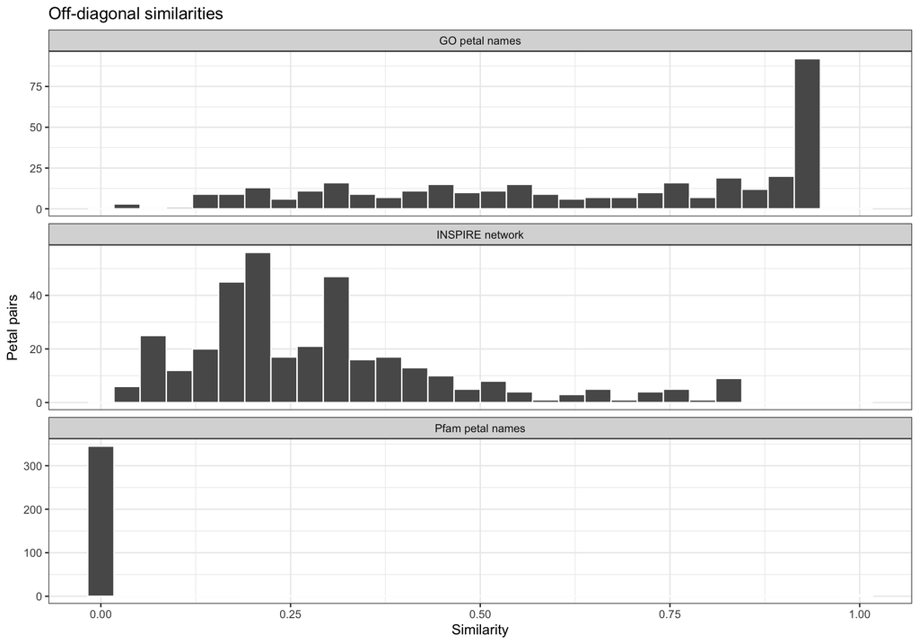

```r
all_scores <- bind_rows(
  matrix_to_long(inspire_similarity, "INSPIRE network"),
  matrix_to_long(go_similarity, "GO petal names"),
  matrix_to_long(pfam_similarity, "Pfam petal names")
)

write_csv(
  all_scores,
  file.path(params$output_dir, "all_similarity_pairs_long.csv")
)

ggplot(all_scores, aes(score)) +
  geom_histogram(bins = 30, color = "white") +
  facet_wrap(~method, ncol = 1, scales = "free_y") +
  theme_bw() +
  labs(
    title = "Off-diagonal similarities",
    x = "Similarity",
    y = "Petal pairs"
  )
```

# 8 INSPIRE threshold grid search: 0.45 through 0.70

```r
thresholds <- seq(
  from = as.numeric(params$threshold_min),
  to = as.numeric(params$threshold_max),
  by = as.numeric(params$threshold_step)
)

if (length(thresholds) < 1) {
  stop("Threshold grid is empty. Check threshold_min, threshold_max, and threshold_step.")
}

inspire_long <- matrix_to_long(inspire_similarity, "INSPIRE")
complete_tree <- hclust(as.dist(1 - inspire_similarity), method = "complete")

# Preallocate the summary table. This avoids bind_rows/list-construction issues.
grid_summary <- data.frame(
  threshold_index = seq_along(thresholds),
  threshold = thresholds,
  retained_edges = integer(length(thresholds)),
  retained_fraction = numeric(length(thresholds)),
  isolated_petals = integer(length(thresholds)),
  connected_components = integer(length(thresholds)),
  largest_component = integer(length(thresholds)),
  complete_linkage_clusters = integer(length(thresholds)),
  walktrap_clusters = integer(length(thresholds)),
  complete_ari_previous = rep(NA_real_, length(thresholds)),
  component_ari_previous = rep(NA_real_, length(thresholds)),
  walktrap_ari_previous = rep(NA_real_, length(thresholds))
)

# Preallocate one assignment matrix per clustering method.
complete_assignment_matrix <- matrix(
  NA_integer_, nrow = n_petals, ncol = length(thresholds),
  dimnames = list(petal_names, paste0("t", seq_along(thresholds)))
)
component_assignment_matrix <- complete_assignment_matrix
walktrap_assignment_matrix <- complete_assignment_matrix

for (index in seq_along(thresholds)) {
  threshold <- thresholds[index]

  # Complete-linkage clusters at this threshold.
  complete_membership <- cutree(complete_tree, h = 1 - threshold)
  complete_membership <- renumber_clusters(complete_membership, petal_names)
  complete_assignment_matrix[, index] <- complete_membership[petal_names]

  # Weighted graph containing only INSPIRE scores above the threshold.
  retained_edges <- inspire_long |>
    dplyr::filter(score > threshold) |>
    dplyr::transmute(from = petal_a, to = petal_b, weight = score)

  graph <- igraph::graph_from_data_frame(
    retained_edges,
    directed = FALSE,
    vertices = data.frame(name = petal_names)
  )

  graph_components <- igraph::components(graph)
  component_membership <- renumber_clusters(
    graph_components$membership,
    petal_names
  )
  component_assignment_matrix[, index] <- component_membership[petal_names]

  if (igraph::ecount(graph) > 0) {
    walktrap_result <- igraph::cluster_walktrap(
      graph,
      weights = igraph::E(graph)$weight
    )
    walktrap_membership <- renumber_clusters(
      igraph::membership(walktrap_result),
      petal_names
    )
  } else {
    walktrap_membership <- setNames(seq_along(petal_names), petal_names)
  }
  walktrap_assignment_matrix[, index] <- walktrap_membership[petal_names]

  grid_summary$retained_edges[index] <- nrow(retained_edges)
  grid_summary$retained_fraction[index] <- nrow(retained_edges) / nrow(inspire_long)
  grid_summary$isolated_petals[index] <- sum(igraph::degree(graph) == 0)
  grid_summary$connected_components[index] <- graph_components$no
  grid_summary$largest_component[index] <- max(graph_components$csize)
  grid_summary$complete_linkage_clusters[index] <- length(unique(complete_membership))
  grid_summary$walktrap_clusters[index] <- length(unique(walktrap_membership))

  if (index > 1) {
    grid_summary$complete_ari_previous[index] <- adjusted_rand_index(
      complete_assignment_matrix[, index - 1],
      complete_assignment_matrix[, index]
    )
    grid_summary$component_ari_previous[index] <- adjusted_rand_index(
      component_assignment_matrix[, index - 1],
      component_assignment_matrix[, index]
    )
    grid_summary$walktrap_ari_previous[index] <- adjusted_rand_index(
      walktrap_assignment_matrix[, index - 1],
      walktrap_assignment_matrix[, index]
    )
  }
}

# Convert assignment matrices to stable long-form tables.
assignment_matrix_to_long <- function(m, thresholds) {
  rows <- vector("list", ncol(m))
  for (index in seq_len(ncol(m))) {
    rows[[index]] <- data.frame(
      threshold_index = index,
      threshold = thresholds[index],
      petal = rownames(m),
      cluster = as.integer(m[, index]),
      stringsAsFactors = FALSE
    )
  }
  dplyr::bind_rows(rows)
}

complete_grid <- assignment_matrix_to_long(complete_assignment_matrix, thresholds)
component_grid <- assignment_matrix_to_long(component_assignment_matrix, thresholds)
walktrap_grid <- assignment_matrix_to_long(walktrap_assignment_matrix, thresholds)

if (nrow(grid_summary) != length(thresholds)) {
  stop(
    "Internal threshold-grid error: expected ", length(thresholds),
    " summary rows, obtained ", nrow(grid_summary)
  )
}

write_csv(
  grid_summary,
  file.path(params$output_dir, "inspire_threshold_grid_summary.csv")
)
write_csv(
  complete_grid,
  file.path(params$output_dir, "inspire_complete_linkage_grid_assignments.csv")
)
write_csv(
  component_grid,
  file.path(params$output_dir, "inspire_component_grid_assignments.csv")
)
write_csv(
  walktrap_grid,
  file.path(params$output_dir, "inspire_walktrap_grid_assignments.csv")
)

grid_summary
```

```
##    threshold_index threshold retained_edges retained_fraction isolated_petals
## 1                1     0.450             51        0.14529915               9
## 2                2     0.475             45        0.12820513               9
## 3                3     0.500             41        0.11680912               9
## 4                4     0.525             36        0.10256410              10
## 5                5     0.550             31        0.08831909              13
## 6                6     0.575             28        0.07977208              13
## 7                7     0.600             28        0.07977208              13
## 8                8     0.625             26        0.07407407              13
## 9                9     0.650             22        0.06267806              15
## 10              10     0.675             20        0.05698006              15
## 11              11     0.700             19        0.05413105              15
##    connected_components largest_component complete_linkage_clusters
## 1                    10                18                        18
## 2                    10                18                        19
```

[output cut: 33 more lines]

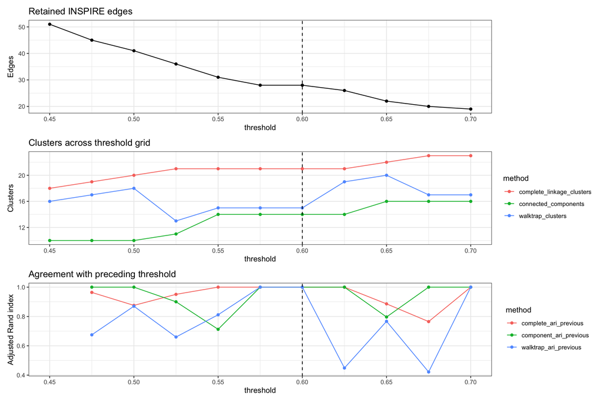

```r
p_edges <- ggplot(grid_summary, aes(threshold, retained_edges)) +
  geom_line() + geom_point() +
  geom_vline(xintercept = params$selected_threshold, linetype = 2) +
  theme_bw() + labs(title = "Retained INSPIRE edges", y = "Edges")

cluster_counts <- grid_summary |>
  select(threshold, complete_linkage_clusters, connected_components, walktrap_clusters) |>
  pivot_longer(-threshold, names_to = "method", values_to = "clusters")

p_clusters <- ggplot(cluster_counts, aes(threshold, clusters, color = method)) +
  geom_line() + geom_point() +
  geom_vline(xintercept = params$selected_threshold, linetype = 2) +
  theme_bw() + labs(title = "Clusters across threshold grid", y = "Clusters")

ari_long <- grid_summary |>
  select(threshold, complete_ari_previous, component_ari_previous, walktrap_ari_previous) |>
  pivot_longer(-threshold, names_to = "method", values_to = "ARI")

p_ari <- ggplot(ari_long, aes(threshold, ARI, color = method)) +
  geom_line() + geom_point() +
  geom_vline(xintercept = params$selected_threshold, linetype = 2) +
  theme_bw() +
  labs(title = "Agreement with preceding threshold", y = "Adjusted Rand index")

p_edges + p_clusters + p_ari + plot_layout(ncol = 1)
```

# 9 Network gallery for every threshold

The same node coordinates are used at every threshold so that changes across the grid reflect edge removal rather than arbitrary layout changes. Node colors show weighted Walktrap communities at each threshold. Square nodes are isolates.

```r
lowest_threshold <- min(thresholds)
lowest_edges <- inspire_long |>
  dplyr::filter(score > lowest_threshold) |>
  dplyr::transmute(from = petal_a, to = petal_b, weight = score)

layout_graph <- igraph::graph_from_data_frame(
  lowest_edges,
  directed = FALSE,
  vertices = data.frame(name = petal_names)
)

set.seed(20260729)
fixed_layout <- igraph::layout_with_fr(
  layout_graph,
  weights = igraph::E(layout_graph)$weight,
  niter = 2000
)
rownames(fixed_layout) <- igraph::V(layout_graph)$name
fixed_layout <- fixed_layout[petal_names, , drop = FALSE]

network_figure_dir <- file.path(params$output_dir, "threshold_networks")
dir.create(network_figure_dir, recursive = TRUE, showWarnings = FALSE)

pdf_file <- file.path(
  params$output_dir,
  "INSPIRE_networks_all_thresholds_0.45_to_0.70.pdf"
)
grDevices::pdf(pdf_file, width = 10, height = 8, onefile = TRUE)

for (index in seq_along(thresholds)) {
  threshold <- thresholds[index]

  edges <- inspire_long |>
    dplyr::filter(score > threshold) |>
    dplyr::transmute(from = petal_a, to = petal_b, weight = score)

  graph <- igraph::graph_from_data_frame(
    edges,
    directed = FALSE,
    vertices = data.frame(name = petal_names)
  )

  walktrap_membership <- walktrap_assignment_matrix[, index]
  component_membership <- component_assignment_matrix[, index]

  palette <- grDevices::hcl.colors(
    max(walktrap_membership),
    palette = "Dark 3"
  )
  node_colors <- palette[walktrap_membership[igraph::V(graph)$name]]

  edge_width <- if (igraph::ecount(graph) > 0) {
    1 + 6 * (igraph::E(graph)$weight - threshold) / max(1e-12, 1 - threshold)
  } else {
    numeric(0)
  }

  node_degree <- igraph::degree(graph)
  node_frame <- ifelse(node_degree == 0, "black", "grey30")
  node_shape <- ifelse(node_degree == 0, "square", "circle")

  title_text <- paste0(
    "INSPIRE score > ", sprintf("%.3f", threshold),
    " | edges: ", nrow(edges),
    " | components: ", length(unique(component_membership)),
    " | Walktrap groups: ", length(unique(walktrap_membership)),
    " | isolates: ", sum(node_degree == 0)
  )

  draw_network <- function() {
    plot(
      graph,
      layout = fixed_layout[igraph::V(graph)$name, , drop = FALSE],
      vertex.color = node_colors,
      vertex.frame.color = node_frame,
      vertex.shape = node_shape,
      vertex.size = 24,
      vertex.label.cex = 0.82,
      vertex.label.color = "black",
      edge.width = edge_width,
      edge.color = grDevices::adjustcolor("grey35", alpha.f = 0.58),
      main = title_text,
      margin = 0.12
    )
  }

  draw_network()

  png_file <- file.path(
    network_figure_dir,
    paste0("INSPIRE_threshold_", sprintf("%.3f", threshold), ".png")
  )
  grDevices::png(png_file, width = 1800, height = 1400, res = 180)
  draw_network()
  grDevices::dev.off()

  cat("\n\n## Threshold ", sprintf("%.3f", threshold), "\n\n", sep = "")
  cat(
    "Retained edges: ", nrow(edges),
    "; connected components: ", length(unique(component_membership)),
    "; Walktrap communities: ", length(unique(walktrap_membership)),
    "; isolates: ", sum(node_degree == 0), ".\n\n",
    sep = ""
  )
  print(knitr::include_graphics(png_file))
  cat("\n\n")
}
```

## 9.1 Threshold 0.450

Retained edges: 51; connected components: 10; Walktrap communities: 16; isolates: 9.

[1] “../reports/clustering/threshold_networks/INSPIRE_threshold_0.450.png” attr(,“class”) [1] “knit_image_paths” “knit_asis”

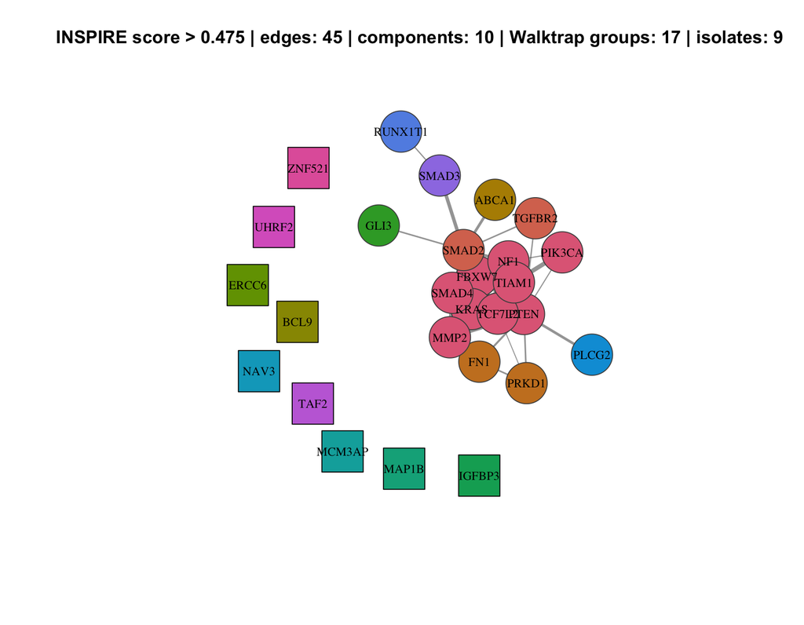

## 9.2 Threshold 0.475

Retained edges: 45; connected components: 10; Walktrap communities: 17; isolates: 9.

[1] “../reports/clustering/threshold_networks/INSPIRE_threshold_0.475.png” attr(,“class”) [1] “knit_image_paths” “knit_asis”

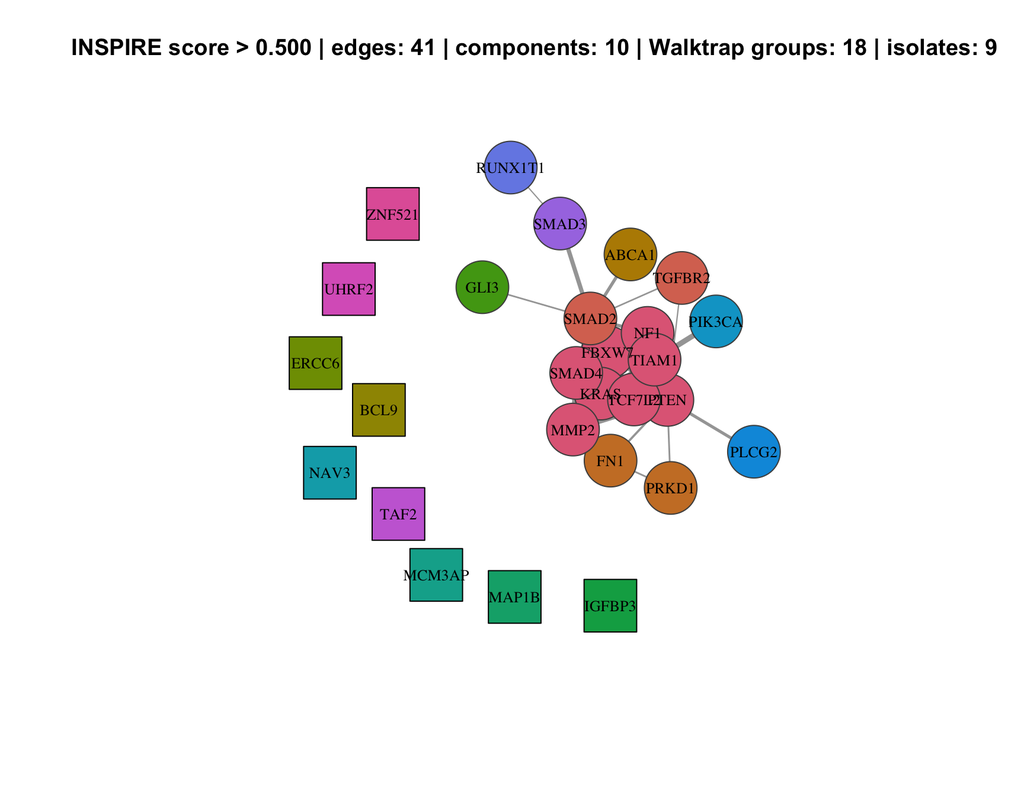

## 9.3 Threshold 0.500

Retained edges: 41; connected components: 10; Walktrap communities: 18; isolates: 9.

[1] “../reports/clustering/threshold_networks/INSPIRE_threshold_0.500.png” attr(,“class”) [1] “knit_image_paths” “knit_asis”

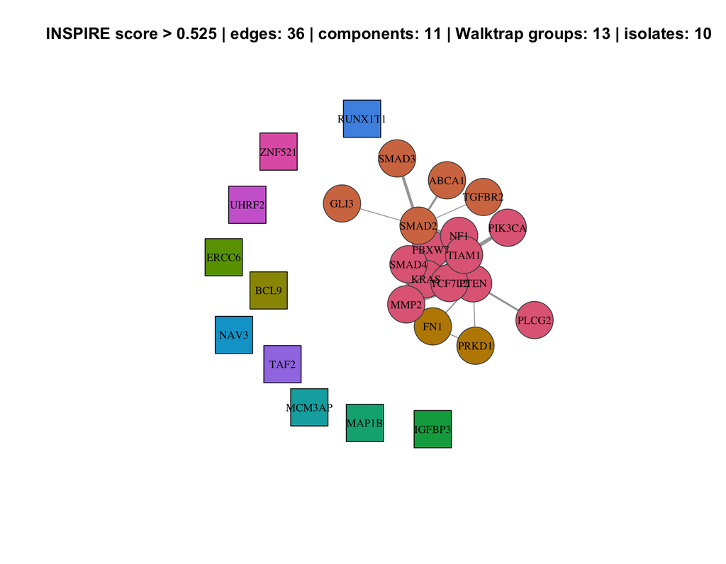

## 9.4 Threshold 0.525

Retained edges: 36; connected components: 11; Walktrap communities: 13; isolates: 10.

[1] “../reports/clustering/threshold_networks/INSPIRE_threshold_0.525.png” attr(,“class”) [1] “knit_image_paths” “knit_asis”

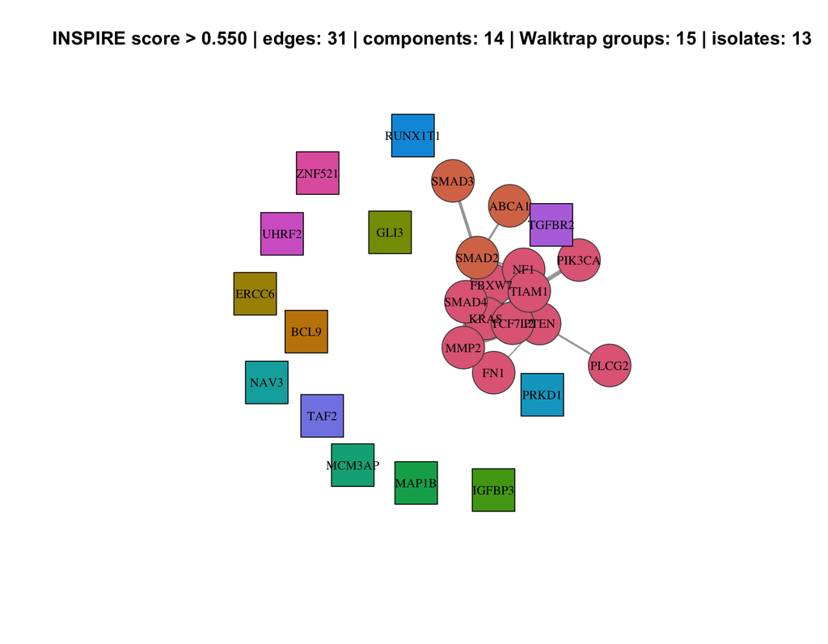

## 9.5 Threshold 0.550

Retained edges: 31; connected components: 14; Walktrap communities: 15; isolates: 13.

[1] “../reports/clustering/threshold_networks/INSPIRE_threshold_0.550.png” attr(,“class”) [1] “knit_image_paths” “knit_asis”

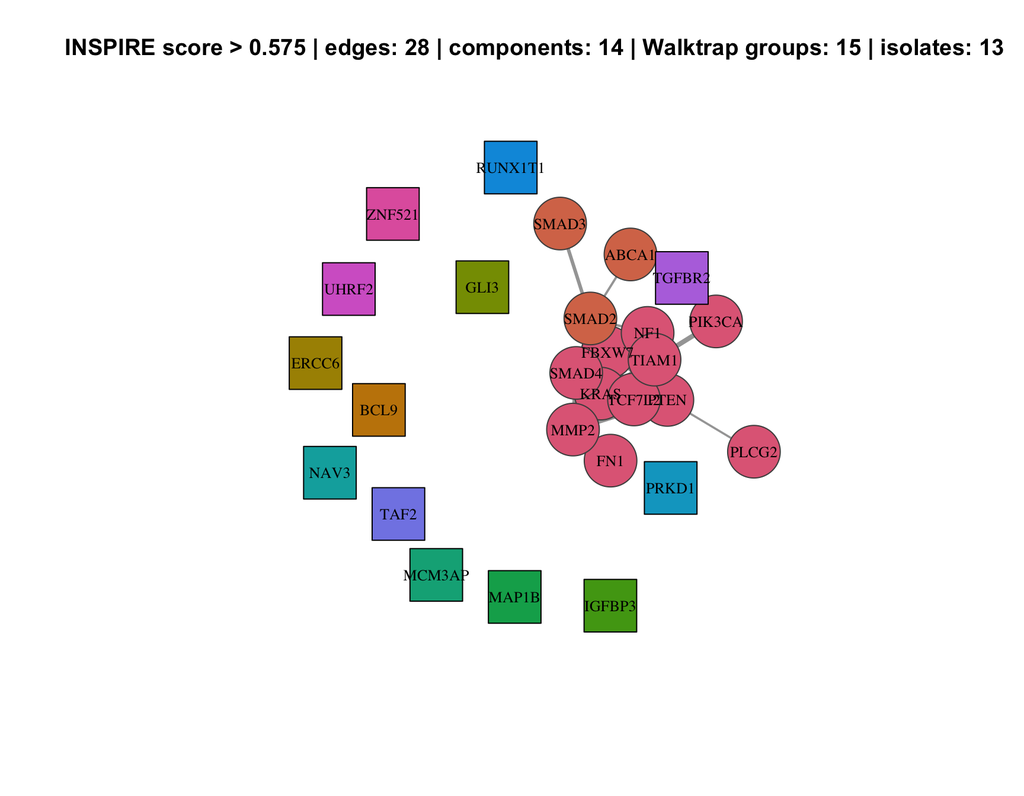

## 9.6 Threshold 0.575

Retained edges: 28; connected components: 14; Walktrap communities: 15; isolates: 13.

[1] “../reports/clustering/threshold_networks/INSPIRE_threshold_0.575.png” attr(,“class”) [1] “knit_image_paths” “knit_asis”

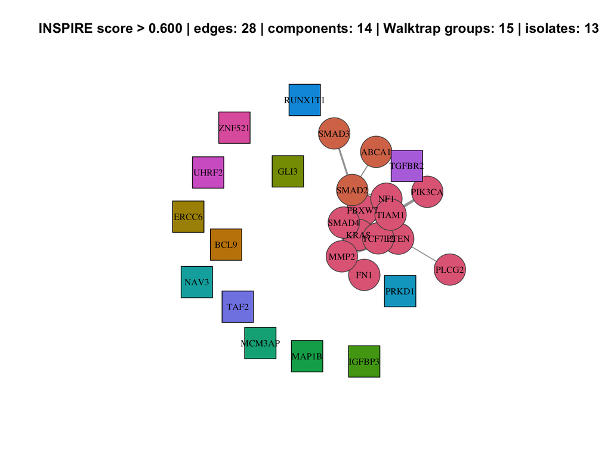

## 9.7 Threshold 0.600

Retained edges: 28; connected components: 14; Walktrap communities: 15; isolates: 13.

[1] “../reports/clustering/threshold_networks/INSPIRE_threshold_0.600.png” attr(,“class”) [1] “knit_image_paths” “knit_asis”

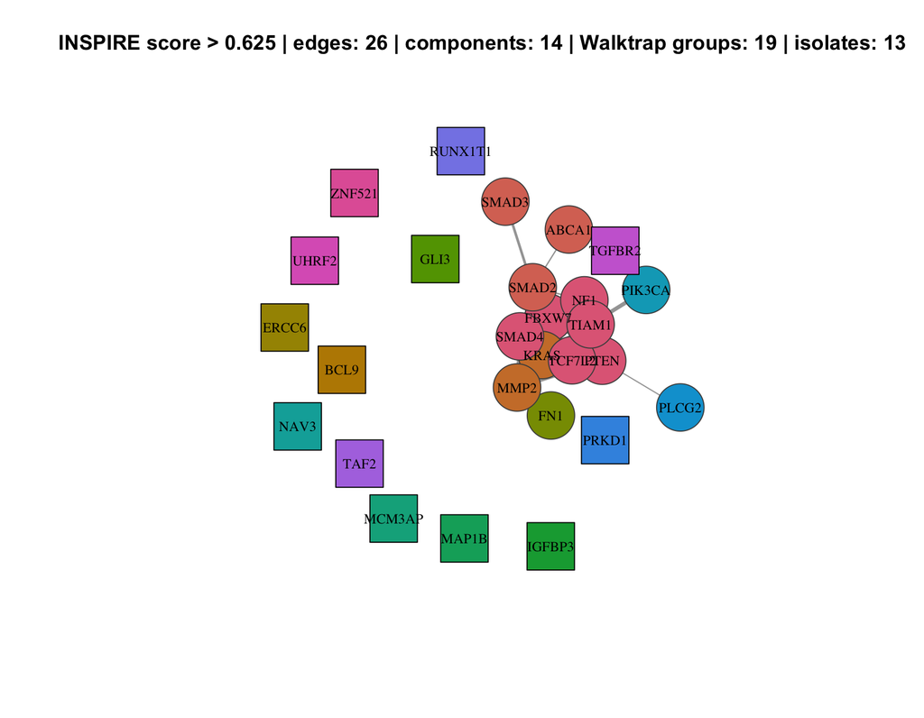

## 9.8 Threshold 0.625

Retained edges: 26; connected components: 14; Walktrap communities: 19; isolates: 13.

[1] “../reports/clustering/threshold_networks/INSPIRE_threshold_0.625.png” attr(,“class”) [1] “knit_image_paths” “knit_asis”

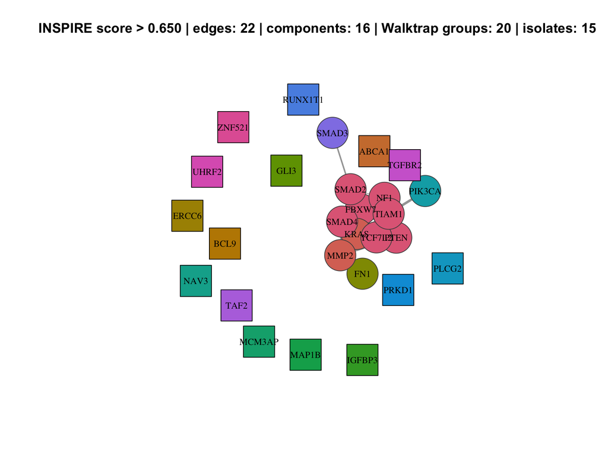

## 9.9 Threshold 0.650

Retained edges: 22; connected components: 16; Walktrap communities: 20; isolates: 15.

[1] “../reports/clustering/threshold_networks/INSPIRE_threshold_0.650.png” attr(,“class”) [1] “knit_image_paths” “knit_asis”

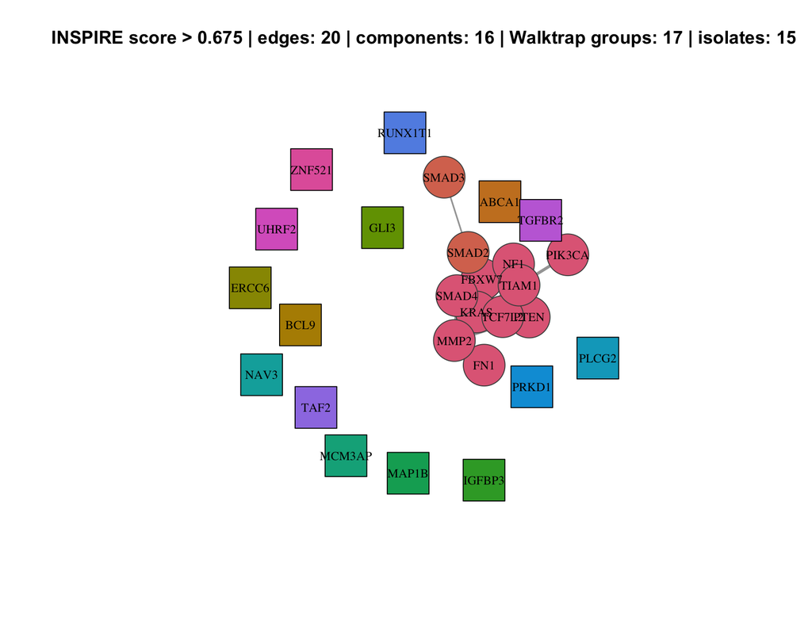

## 9.10 Threshold 0.675

Retained edges: 20; connected components: 16; Walktrap communities: 17; isolates: 15.

[1] “../reports/clustering/threshold_networks/INSPIRE_threshold_0.675.png” attr(,“class”) [1] “knit_image_paths” “knit_asis”

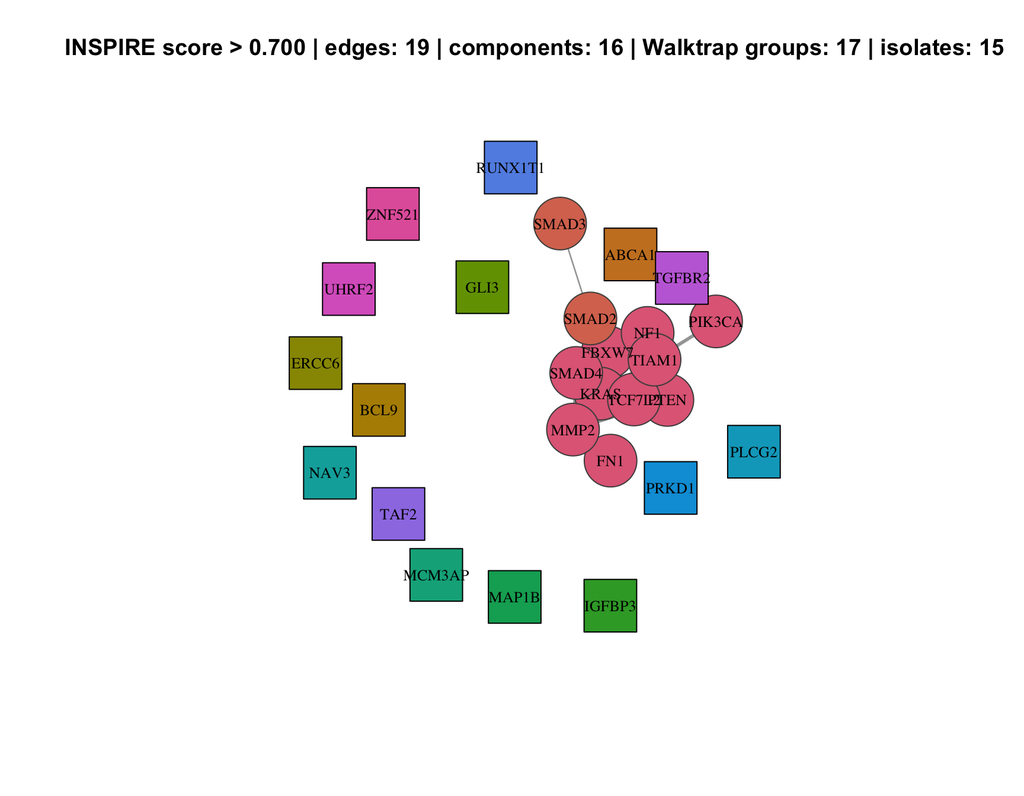

## 9.11 Threshold 0.700

Retained edges: 19; connected components: 16; Walktrap communities: 17; isolates: 15.

[1] “../reports/clustering/threshold_networks/INSPIRE_threshold_0.700.png” attr(,“class”) [1] “knit_image_paths” “knit_asis”

```r
grDevices::dev.off()
```

pdf 3

```r
cat(
  "\n\nA multipage PDF containing all threshold networks was written to `",
  pdf_file,
  "`.\n\n",
  sep = ""
)
```

A multipage PDF containing all threshold networks was written to `../reports/clustering/INSPIRE_networks_all_thresholds_0.45_to_0.70.pdf`.

# 10 How to interpret the threshold grid

The grid is a sensitivity analysis. The ARI columns compare each clustering with the immediately preceding threshold and are not accuracy scores against biological ground truth.

A useful threshold interval has stable assignments, gradual edge loss, limited growth in isolates, and persistent communities across several consecutive thresholds.

```r
threshold_interpretation <- grid_summary |>
  dplyr::mutate(
    edge_loss_from_previous = retained_edges - dplyr::lag(retained_edges),
    isolate_change = isolated_petals - dplyr::lag(isolated_petals),
    largest_component_change = largest_component - dplyr::lag(largest_component),
    minimum_adjacent_ari = pmin(
      complete_ari_previous,
      component_ari_previous,
      walktrap_ari_previous,
      na.rm = TRUE
    ),
    stable_transition = dplyr::if_else(
      is.na(minimum_adjacent_ari),
      FALSE,
      minimum_adjacent_ari >= 0.80 & abs(isolate_change) <= 2
    )
  )

write_csv(
  threshold_interpretation,
  file.path(params$output_dir, "inspire_threshold_interpretation.csv")
)

threshold_interpretation
```

```
##    threshold_index threshold retained_edges retained_fraction isolated_petals
## 1                1     0.450             51        0.14529915               9
## 2                2     0.475             45        0.12820513               9
## 3                3     0.500             41        0.11680912               9
## 4                4     0.525             36        0.10256410              10
## 5                5     0.550             31        0.08831909              13
## 6                6     0.575             28        0.07977208              13
## 7                7     0.600             28        0.07977208              13
## 8                8     0.625             26        0.07407407              13
## 9                9     0.650             22        0.06267806              15
## 10              10     0.675             20        0.05698006              15
## 11              11     0.700             19        0.05413105              15
##    connected_components largest_component complete_linkage_clusters
## 1                    10                18                        18
## 2                    10                18                        19
```

[output cut: 45 more lines]

# 11 Selected-threshold INSPIRE results

```r
selected_index <- which.min(abs(thresholds - params$selected_threshold))
selected_threshold <- thresholds[selected_index]

selected_complete <- complete_grid |>
  filter(threshold == selected_threshold) |>
  select(petal, complete_linkage_cluster = cluster)

selected_components <- component_grid |>
  filter(threshold == selected_threshold) |>
  select(petal, connected_component = cluster)

selected_walktrap <- walktrap_grid |>
  filter(threshold == selected_threshold) |>
  select(petal, walktrap_cluster = cluster)

selected_assignments <- selected_complete |>
  left_join(selected_components, by = "petal") |>
  left_join(selected_walktrap, by = "petal") |>
  arrange(complete_linkage_cluster, walktrap_cluster, petal)

write_csv(
  selected_assignments,
  file.path(params$output_dir, "inspire_selected_threshold_clusters.csv")
)

selected_assignments
```

```
##      petal complete_linkage_cluster connected_component walktrap_cluster
## 1    FBXW7                        1                   1                1
## 2      NF1                        1                   1                1
## 3     PTEN                        1                   1                1
## 4    TIAM1                        1                   1                1
## 5    SMAD4                        2                   1                1
## 6   TCF7L2                        2                   1                1
## 7    SMAD2                        2                   1                2
## 8      FN1                        3                   1                1
## 9     MMP2                        3                   1                1
## 10   ABCA1                        4                   1                2
## 11    BCL9                        5                   2                3
## 12   ERCC6                        6                   3                4
## 13    GLI3                        7                   4                5
## 14  IGFBP3                        8                   5                6
## 15    KRAS                        9                   1                1
## 16   MAP1B                       10                   6                7
## 17  MCM3AP                       11                   7                8
## 18    NAV3                       12                   8                9
## 19  PIK3CA                       13                   1                1
## 20   PLCG2                       14                   1                1
## 21   PRKD1                       15                   9               10
## 22 RUNX1T1                       16                  10               11
## 23   SMAD3                       17                   1                2
## 24    TAF2                       18                  11               12
## 25  TGFBR2                       19                  12               13
## 26   UHRF2                       20                  13               14
## 27  ZNF521                       21                  14               15
```

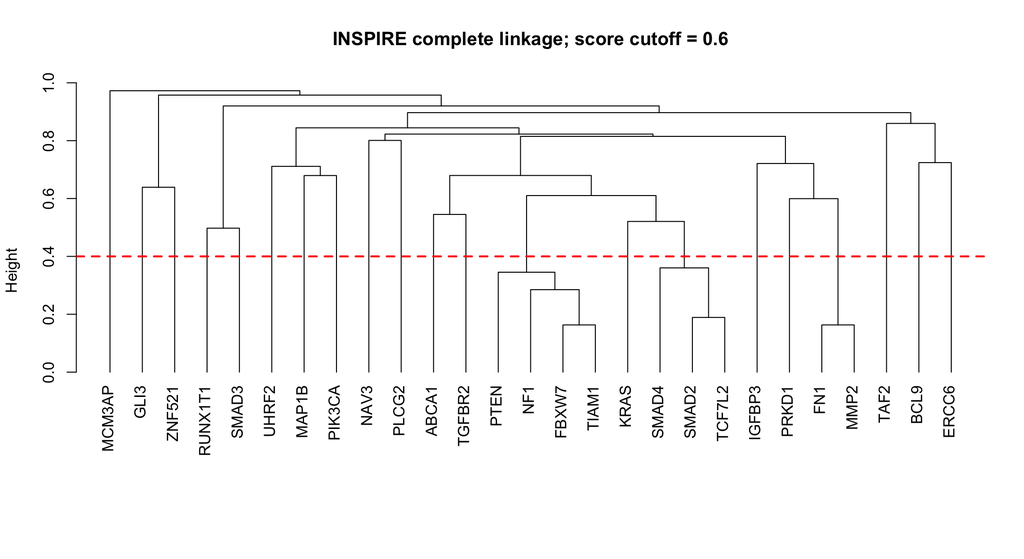

```r
plot(
  complete_tree,
  main = paste0("INSPIRE complete linkage; score cutoff = ", selected_threshold),
  xlab = "",
  sub = "",
  hang = -1
)
abline(h = 1 - selected_threshold, col = "red", lty = 2, lwd = 2)
```

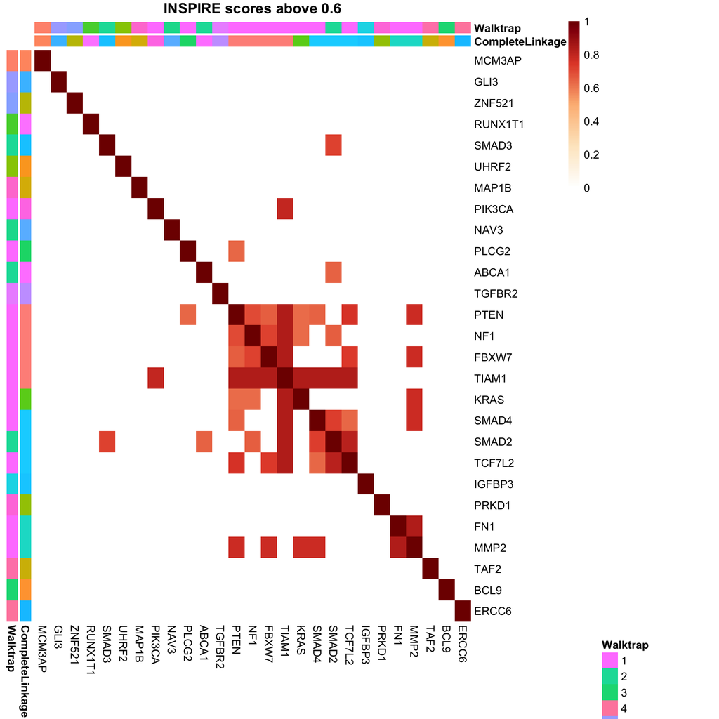

```r
threshold_matrix <- inspire_similarity
threshold_matrix[threshold_matrix <= selected_threshold] <- 0
diag(threshold_matrix) <- 1

ordered_petals <- complete_tree$labels[complete_tree$order]
annotation <- data.frame(
  CompleteLinkage = factor(selected_complete$complete_linkage_cluster[
    match(ordered_petals, selected_complete$petal)
  ]),
  Walktrap = factor(selected_walktrap$walktrap_cluster[
    match(ordered_petals, selected_walktrap$petal)
  ]),
  row.names = ordered_petals
)

pheatmap(
  threshold_matrix[ordered_petals, ordered_petals],
  cluster_rows = FALSE,
  cluster_cols = FALSE,
  annotation_row = annotation,
  annotation_col = annotation,
  main = paste0("INSPIRE scores above ", selected_threshold),
  color = colorRampPalette(c("white", "#fee8c8", "#fdbb84", "#e34a33", "#7f0000"))(100),
  border_color = NA
)
```

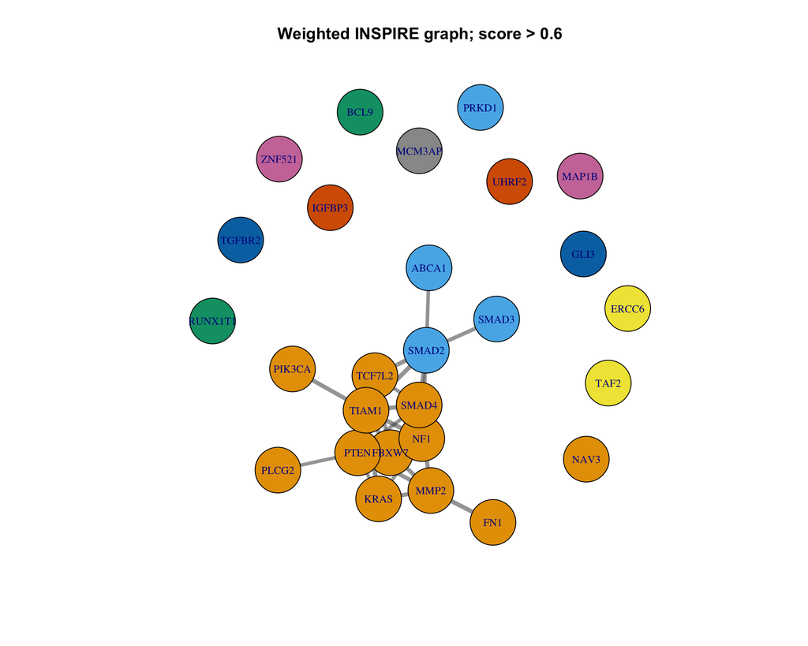

```r
selected_edges <- inspire_long |>
  filter(score > selected_threshold) |>
  transmute(from = petal_a, to = petal_b, weight = score)

selected_graph <- graph_from_data_frame(
  selected_edges,
  directed = FALSE,
  vertices = tibble(name = petal_names)
)

selected_walktrap_membership <- setNames(
  selected_walktrap$walktrap_cluster,
  selected_walktrap$petal
)

plot(
  selected_graph,
  layout = layout_with_fr(selected_graph),
  vertex.color = selected_walktrap_membership[V(selected_graph)$name],
  vertex.size = 22,
  vertex.label.cex = 0.8,
  edge.width = 1 + 5 * E(selected_graph)$weight,
  edge.color = adjustcolor("grey30", alpha.f = 0.55),
  main = paste0("Weighted INSPIRE graph; score > ", selected_threshold)
)
```

# 12 GO and Pfam petal-name heatmaps

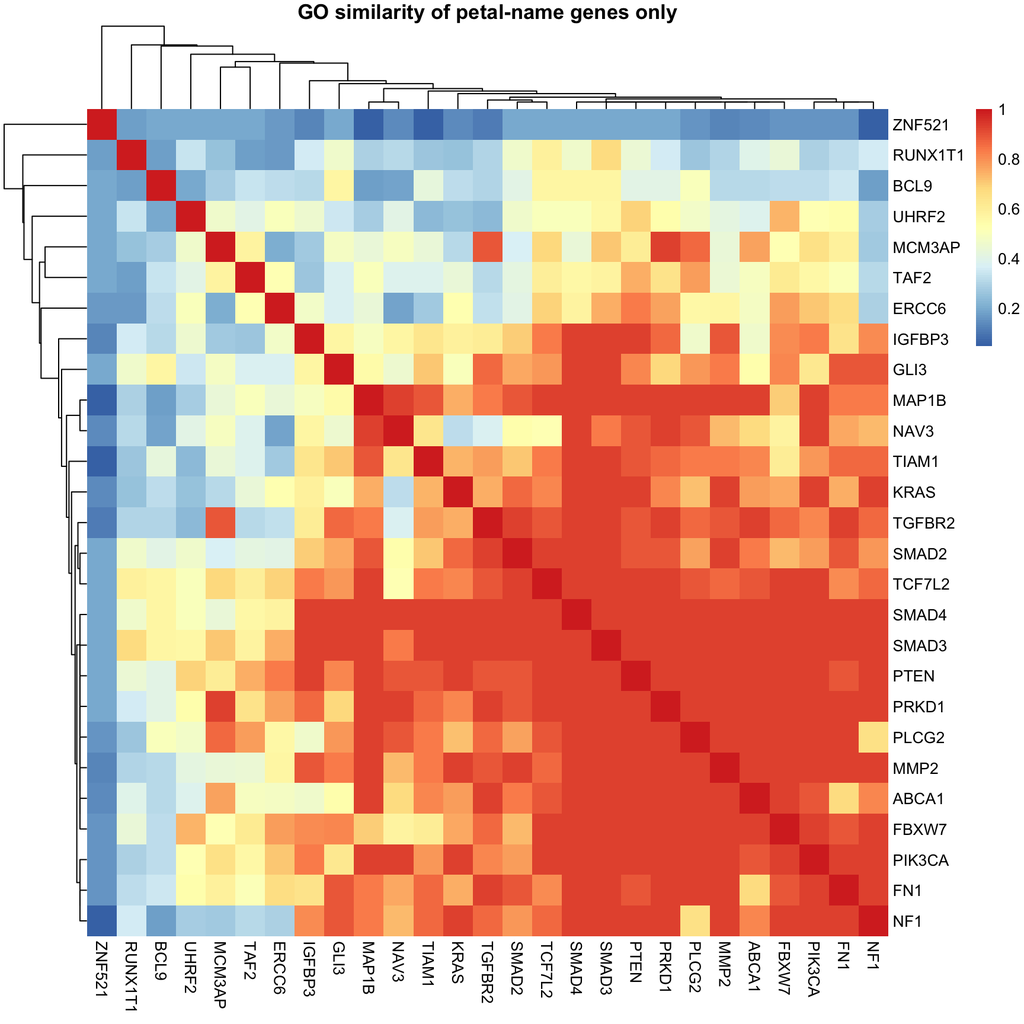

```r
pheatmap(
  go_similarity,
  clustering_distance_rows = as.dist(1 - go_similarity),
  clustering_distance_cols = as.dist(1 - go_similarity),
  clustering_method = "average",
  main = "GO similarity of petal-name genes only",
  border_color = NA
)
```

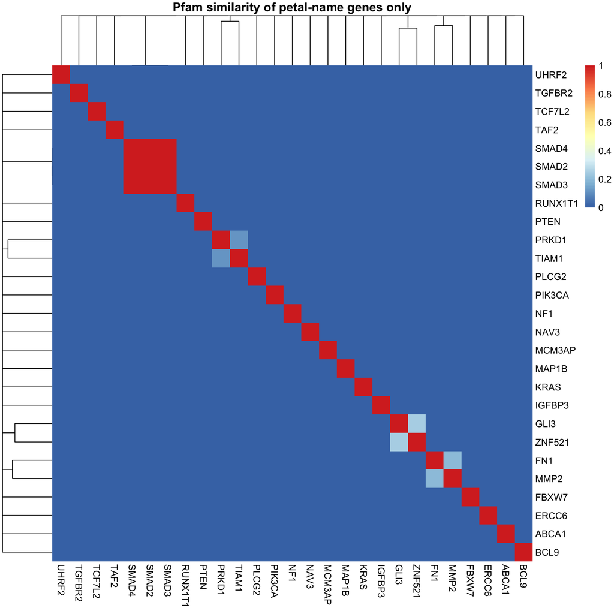

```r
pheatmap(
  pfam_similarity,
  clustering_distance_rows = as.dist(1 - pfam_similarity),
  clustering_distance_cols = as.dist(1 - pfam_similarity),
  clustering_method = "average",
  main = "Pfam similarity of petal-name genes only",
  border_color = NA
)
```

# 13 Matrix correlations

```r
all_wide <- all_scores |>
  select(petal_a, petal_b, method, score) |>
  pivot_wider(names_from = method, values_from = score)

numeric_scores <- all_wide |> select(where(is.numeric))
pearson <- cor(numeric_scores, method = "pearson")
spearman <- cor(numeric_scores, method = "spearman")

write.csv(pearson,
          file.path(params$output_dir, "matrix_correlations_pearson.csv"))
write.csv(spearman,
          file.path(params$output_dir, "matrix_correlations_spearman.csv"))

pearson
```

```
##                  INSPIRE network GO petal names Pfam petal names
## INSPIRE network        1.0000000     0.62197168       0.19522496
## GO petal names         0.6219717     1.00000000       0.09532236
## Pfam petal names       0.1952250     0.09532236       1.00000000
```

```r
spearman
```

```
##                  INSPIRE network GO petal names Pfam petal names
## INSPIRE network        1.0000000     0.70800708       0.17754342
## GO petal names         0.7080071     1.00000000       0.09409824
## Pfam petal names       0.1775434     0.09409824       1.00000000
```

# 14 Metadata and disconnect

```r
metadata <- DBI::dbGetQuery(con, "SELECT key, value FROM metadata ORDER BY key")
write_csv(metadata, file.path(params$output_dir, "database_metadata.csv"))
metadata
```

```
##                                                       key
## 1                           annotation_loader_last_run_at
## 2                               annotation_loader_version
## 3                                   created_or_updated_at
## 4                                  duplicate_score_policy
## 5                                          edge_direction
## 6                                   go_annotation_version
## 7                                        go_aspect_policy
## 8                                             go_gaf_file
## 9                                        go_gaf_loaded_at
## 10                                          go_gaf_sha256
## 11                                       go_ic_population
## 12                                   go_ic_total_proteins
## 13                                          go_not_policy
## 14                                            go_obo_file
```

[output cut: 71 more lines]

```r
DBI::dbDisconnect(con)
```